# HW3

Jian Cui

Oct 12 2020

```r
library(tidyverse)
library(magrittr)
library(ggplot2)
library(leaflet)
library(htmltools)
library(kableExtra)
```

# Problem 1 : COVID-19

## 1.Correctly format the dates in “Date.of.birth”, “First.day.of.symptoms”, “Date.of.outcome” and “Date.of.diagnosis”.

```r
data <-read.csv('covid.csv',sep=',',header=TRUE)
covid <- data.frame(data)
covid$Date.of.birth <- as.Date(covid$Date.of.birth,format = "%Y-%m-%d")
covid$First.day.of.symptoms <- as.Date(covid$First.day.of.symptoms,format = "%Y-%m-%d")
covid$Date.of.outcome <- as.Date(covid$Date.of.outcome,format = "%Y-%m-%d")
covid$Date.of.diagnosis <- as.Date(covid$Date.of.diagnosis,format = "%Y-%m-%d")
covid %>%
  head(3) %>%
knitr::kable()  %>%  kable_styling(bootstrap_options = c("striped", "hover"))
```

| X | Date.of.birth | Hospitalization.type | Symptoms | First.day.of.symptoms | Outcome | Date.of.outcome | Date.of.diagnosis | Epidemiological.link…Notes |
| --- | --- | --- | --- | --- | --- | --- | --- | --- |
| 1 | 1956-01-22 | Home isolation | Symptomatic | 2020-02-25 | Healed | 2020-04-15 | 2020-03-05 | In contact with a positive patient (outside province) in a club. Pediatrician |
| 2 | 1943-05-03 | Intensive care | Symptomatic | 2020-02-27 | Deceased | 2020-03-14 | 2020-03-06 | None of the common COVID symptoms |
| 3 | 1996-10-16 | Home isolation | Symptomatic | 2020-02-27 | Healed | 2020-04-15 | 2020-03-07 | Works in the Police. Has been close contact with positive patient (outside province) |

## 2.Format “Hospitalization.type”, “Symptoms” and “Outcome” as factors and “Epidemiological.link…Notes” as character.

```r
covid$Hospitalization.type <- as.factor(covid$Hospitalization.type)
covid$Symptoms <- as.factor(covid$Symptoms)
covid$Outcome <- as.factor(covid$Outcome)
covid$Epidemiological.link...Notes <- as.character(covid$Epidemiological.link...Notes)
```

## 3.Create a three-dimensional table reporting the three factors from the previous question. Hint: use the function table() with the variables of interest.

```r
factor_3 <- as.data.frame(table(covid$Hospitalization.type,covid$Symptoms,covid$Outcome))
factor_3 %>%
  knitr::kable()  %>%  kable_styling(bootstrap_options = c("striped", "hover"))
```

| Var1 | Var2 | Var3 | Freq |
| --- | --- | --- | --- |
| Home isolation | Asymptomatic | Deceased | 2 |
| Intensive care | Asymptomatic | Deceased | 0 |
| Non-Intensive care hospitalization | Asymptomatic | Deceased | 7 |
| Home isolation | Symptomatic | Deceased | 15 |
| Intensive care | Symptomatic | Deceased | 15 |
| Non-Intensive care hospitalization | Symptomatic | Deceased | 133 |
| Home isolation | Asymptomatic | Disease in progress | 64 |
| Intensive care | Asymptomatic | Disease in progress | 0 |
| Non-Intensive care hospitalization | Asymptomatic | Disease in progress | 4 |
| Home isolation | Symptomatic | Disease in progress | 20 |
| Intensive care | Symptomatic | Disease in progress | 2 |
| Non-Intensive care hospitalization | Symptomatic | Disease in progress | 20 |
| Home isolation | Asymptomatic | Healed | 153 |
| Intensive care | Asymptomatic | Healed | 1 |
| Non-Intensive care hospitalization | Asymptomatic | Healed | 17 |
| Home isolation | Symptomatic | Healed | 379 |
| Intensive care | Symptomatic | Healed | 9 |
| Non-Intensive care hospitalization | Symptomatic | Healed | 261 |

## 4.Using the table object created in the previous question, subset it in order to create the following table.

```r
factor_4 =as.data.frame(subset(factor_3,(Var1 %in% c("Home isolation","Intensive care"))&
                                 (Var3 %in% c("Disease in progress","Healed"))&(Var2 %in% c("Asymptomatic")),
                               select=c(Var1,Var3,Freq)))
factor_4$Var1<- as.factor(as.character(factor_4$Var1))
factor_4$Var3<- as.factor(as.character(factor_4$Var3))
xtabs(Freq ~ Var1+Var3, data= factor_4)
```

```
##                 Var3
## Var1             Disease in progress Healed
##   Home isolation                  64    153
##   Intensive care                   0      1
```

## 5.Order the data based on the date of diagnosis (from first to most recent).

```r
covid %>%
  arrange(Date.of.diagnosis) %>%
  head(5) %>%
  knitr::kable()  %>%  kable_styling(bootstrap_options = c("striped", "hover"))
```

| X | Date.of.birth | Hospitalization.type | Symptoms | First.day.of.symptoms | Outcome | Date.of.outcome | Date.of.diagnosis | Epidemiological.link…Notes |
| --- | --- | --- | --- | --- | --- | --- | --- | --- |
| 1 | 1956-01-22 | Home isolation | Symptomatic | 2020-02-25 | Healed | 2020-04-15 | 2020-03-05 | In contact with a positive patient (outside province) in a club. Pediatrician |
| 2 | 1943-05-03 | Intensive care | Symptomatic | 2020-02-27 | Deceased | 2020-03-14 | 2020-03-06 | None of the common COVID symptoms |
| 3 | 1996-10-16 | Home isolation | Symptomatic | 2020-02-27 | Healed | 2020-04-15 | 2020-03-07 | Works in the Police. Has been close contact with positive patient (outside province) |
| 4 | 1989-10-21 | Home isolation | Symptomatic | 2020-02-28 | Healed | 2020-04-19 | 2020-03-07 | Travelled to Lombardia before being tested positive |
| 5 | 1964-12-14 | Non-Intensive care hospitalization | Symptomatic | 2020-02-25 | Healed | 2020-04-19 | 2020-03-07 | Contact with covid positive patients during the course firefighters outside of province on 20.02.2020 |

## 6.Add a column that reports whether or not a case was asymptomatic AND in home isolation. Name the observation “Home_Asymptomatic” if the conditions apply and “Non_Home_Asymptomatic” if not and then produce a bar plot of this new variable.

```r
covid %>%
  mutate(
    ASHI=ifelse(Symptoms=="Asymptomatic"&Hospitalization.type == "Home isolation", "Home_Asymptomatic", "Non_Home_Asymptomatic")) %>%
  head(n=10) %>%
  select(1:5,10) %>%
  knitr::kable()  %>%  kable_styling(bootstrap_options = c("striped", "hover"))
```

| X | Date.of.birth | Hospitalization.type | Symptoms | First.day.of.symptoms | ASHI |
| --- | --- | --- | --- | --- | --- |
| 1 | 1956-01-22 | Home isolation | Symptomatic | 2020-02-25 | Non_Home_Asymptomatic |
| 2 | 1943-05-03 | Intensive care | Symptomatic | 2020-02-27 | Non_Home_Asymptomatic |
| 3 | 1996-10-16 | Home isolation | Symptomatic | 2020-02-27 | Non_Home_Asymptomatic |
| 4 | 1989-10-21 | Home isolation | Symptomatic | 2020-02-28 | Non_Home_Asymptomatic |
| 5 | 1964-12-14 | Non-Intensive care hospitalization | Symptomatic | 2020-02-25 | Non_Home_Asymptomatic |
| 6 | 1952-08-07 | Non-Intensive care hospitalization | Symptomatic | 2020-03-03 | Non_Home_Asymptomatic |
| 7 | 1952-05-11 | Non-Intensive care hospitalization | Symptomatic | 2020-03-01 | Non_Home_Asymptomatic |
| 8 | 1957-03-06 | Home isolation | Symptomatic | 2020-02-27 | Non_Home_Asymptomatic |
| 9 | 1934-01-13 | Home isolation | Symptomatic | 2020-03-09 | Non_Home_Asymptomatic |
| 10 | 1934-04-16 | Non-Intensive care hospitalization | Symptomatic | 2020-03-09 | Non_Home_Asymptomatic |

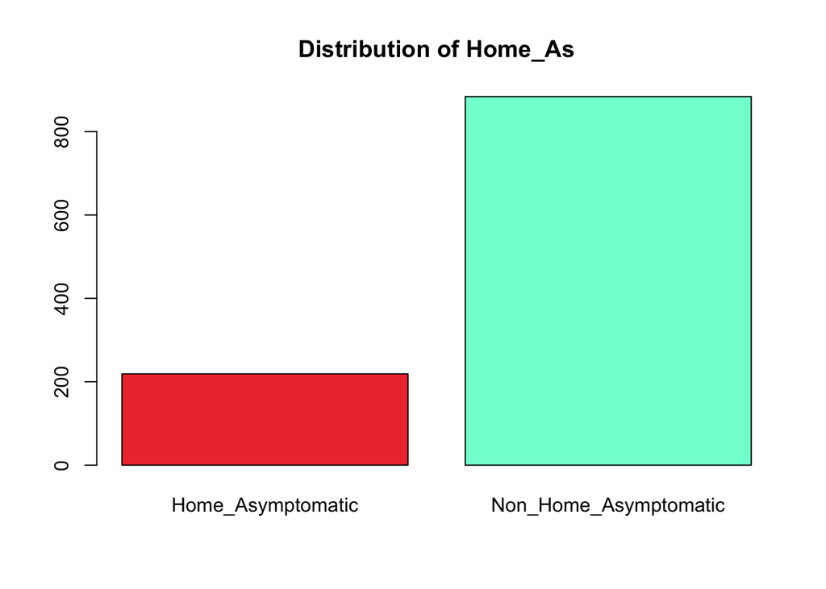

```r
covid_ASHI <- covid %>%
  mutate(
    ASHI = ifelse(Symptoms=="Asymptomatic" & Hospitalization.type == "Home isolation", "Home_Asymptomatic", "Non_Home_Asymptomatic")
     )
ASHI <-table(covid_ASHI$ASHI)
barplot(ASHI, main="Distribution of Home_As",
        col=c("brown2", "aquamarine1"))
```

## 7.Count the number of cases of people born after 1981 and that have healed.

```r
Q7 <- count(covid[(covid$Date.of.birth > "1981-12-31") & (covid$Outcome == "Healed"),])
Q7
```

```
##     n
## 1 152
```

## 8.Count the number of cases that are asymptomatic OR in home isolation (but not both) AND were born before 1982.

```r
covid %>%
  filter((covid$Date.of.birth < "1982-01-01")&
                   ((covid$Symptoms=="Asymptomatic")|(covid$Hospitalization.type == "Home isolation"))&
                   (!(covid$Symptoms=="Asymptomatic"&covid$Hospitalization.type=="Home isolation"))) %>% count()
```

```
##     n
## 1 339
```

## 9.Create a new dataset including only the rows where “Epidemiological.link…Notes” includes the words “contact” OR “symptom” (or both). Hint: you can use the grep() function and tolower().

```r
covidEpi <- covid[(grepl("contact",tolower(covid$Epidemiological.link...Notes))|(grepl("symptom",tolower(covid$Epidemiological.link...Notes)))),]

covidEpi %>%
  head(5) %>%
  select(1:4,9) %>%
  knitr::kable()  %>%  kable_styling(bootstrap_options = c("striped", "hover"))
```

|  | X | Date.of.birth | Hospitalization.type | Symptoms | Epidemiological.link…Notes |
| --- | --- | --- | --- | --- | --- |
| 1 | 1 | 1956-01-22 | Home isolation | Symptomatic | In contact with a positive patient (outside province) in a club. Pediatrician |
| 2 | 2 | 1943-05-03 | Intensive care | Symptomatic | None of the common COVID symptoms |
| 3 | 3 | 1996-10-16 | Home isolation | Symptomatic | Works in the Police. Has been close contact with positive patient (outside province) |
| 5 | 5 | 1964-12-14 | Non-Intensive care hospitalization | Symptomatic | Contact with covid positive patients during the course firefighters outside of province on 20.02.2020 |
| 11 | 11 | 1960-10-11 | Home isolation | Symptomatic | In contact with positive patient (daughter living in Lombardia) |

## 10.In the previous dataset add a column reporting the age (in years, therefore in integer format) of each patient as of October 2nd, 2020. Save this dataset into a .csv file and make it available on your GitHub repository for this assignment.

```r
covidnew <- covidEpi %>%
  mutate(
    age = as.numeric(round((as.Date("2020-10-02") -as.Date(covidEpi$Date.of.birth))/365))
  )
covidnew %>%
  head(5) %>%
  select(1:4,10) %>%
  knitr::kable()  %>%  kable_styling(bootstrap_options = c("striped", "hover"))
```

| X | Date.of.birth | Hospitalization.type | Symptoms | age |
| --- | --- | --- | --- | --- |
| 1 | 1956-01-22 | Home isolation | Symptomatic | 65 |
| 2 | 1943-05-03 | Intensive care | Symptomatic | 77 |
| 3 | 1996-10-16 | Home isolation | Symptomatic | 24 |
| 5 | 1964-12-14 | Non-Intensive care hospitalization | Symptomatic | 56 |
| 11 | 1960-10-11 | Home isolation | Symptomatic | 60 |

```r
write.csv(covidnew,"covid_age.csv")
```

## 11.Produce a pie chart for the type of hospitalization for cases born between 1960 and 1980.

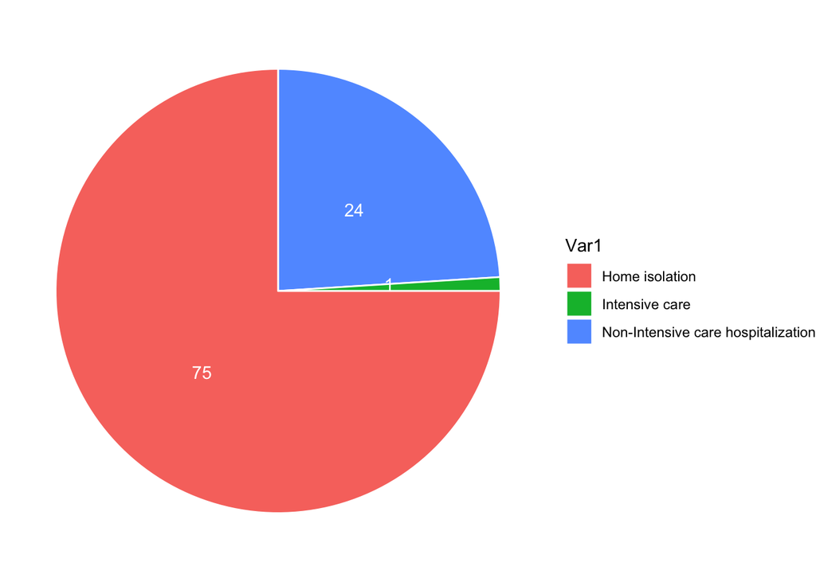

```r
covidpie <- covid[(covid$Date.of.birth > "1959-12-31") & (covid$Date.of.birth < "1981-01-01"),]
piedata <- as.data.frame(table(covidpie$Hospitalization.type))

piedata <- piedata  %>%
  mutate(prop = round(Freq/sum(Freq)*100))
piedata <- piedata %>%
  arrange(desc(Var1)) %>%
  mutate(lab.ypos = round(cumsum(prop) - 0.5*prop))

ggplot(piedata, aes(x="", y=prop, fill=Var1)) +
  geom_bar(width = 1, stat = "identity", color = "white") +
  labs(
    x = "",
    y = ""
  ) +
  coord_polar("y", start=0) +
  geom_text(aes(y = lab.ypos, label = prop), color = "white")+
  theme_void()
```

# Problem 2 : Salary

## 1.Load the data and check the formatting of the variables.

```r
data_ad <-read.csv('adult.csv', sep = ";", header=TRUE)
adult <- data.frame(data_ad)
str(adult)
```

```
## 'data.frame':    32561 obs. of  16 variables:
##  $ X             : int  1 2 3 4 5 6 7 8 9 10 ...
##  $ age           : int  39 50 38 53 28 37 49 52 31 42 ...
##  $ workclass     : chr  " State-gov" " Self-emp-not-inc" " Private" " Private" ...
##  $ fnlwgt        : int  77516 83311 215646 234721 338409 284582 160187 209642 45781 159449 ...
##  $ education     : chr  " Bachelors" " Bachelors" " HS-grad" " 11th" ...
##  $ education.num : int  13 13 9 7 13 14 5 9 14 13 ...
##  $ marital.status: chr  " Never-married" " Married-civ-spouse" " Divorced" " Married-civ-spouse" ...
##  $ occupation    : chr  " Adm-clerical" " Exec-managerial" " Handlers-cleaners" " Handlers-cleaners" ...
##  $ relationship  : chr  " Not-in-family" " Husband" " Not-in-family" " Husband" ...
##  $ race          : chr  " White" " White" " White" " Black" ...
##  $ sex           : chr  " Male" " Male" " Male" " Male" ...
##  $ capital.gain  : int  2174 0 0 0 0 0 0 0 14084 5178 ...
##  $ capital.loss  : int  0 0 0 0 0 0 0 0 0 0 ...
##  $ hours.per.week: int  40 13 40 40 40 40 16 45 50 40 ...
##  $ native.country: chr  " United-States" " United-States" " United-States" " United-States" ...
##  $ NA.           : chr  " <=50K" " <=50K" " <=50K" " <=50K" ...
```

## 2.Rename the last column (currently called “NA”) containing the dichotomous salary information. Assign the name salary to it.

```r
names(adult)[16]="salary"
adult %>%
  head(3) %>%
  select(1:4,16) %>%
  knitr::kable() %>%  kable_styling(bootstrap_options = c("striped", "hover"))
```

| X | age | workclass | fnlwgt | salary |
| --- | --- | --- | --- | --- |
| 1 | 39 | State-gov | 77516 | <=50K |
| 2 | 50 | Self-emp-not-inc | 83311 | <=50K |
| 3 | 38 | Private | 215646 | <=50K |

## 3.The values in salary have a space in front of them (e.g. " >50K"): remove the space from all values (hint: you can use substring()).

```r
adult$salary <- substring(adult$salary, 2, 100)
adult %>%
  head(3) %>%
  select(2:4,16) %>%
  knitr::kable() %>%  kable_styling(bootstrap_options = c("striped", "hover"))
```

| age | workclass | fnlwgt | salary |
| --- | --- | --- | --- |
| 39 | State-gov | 77516 | <=50K |
| 50 | Self-emp-not-inc | 83311 | <=50K |
| 38 | Private | 215646 | <=50K |

## 4.Again, in the variable salary, replace “>50K” with the value 1 and “<=50K” with 0. Make sure to format it as a factor with two levels.

```r
a <- sub(">50K","1",adult$salary)
b <- sub("<=50K","0",a)
adult$salary <- b
adult$salary <- as.factor(adult$salary)
levels(adult$salary)
```

```
## [1] "0" "1"
```

## 5.Use the glm() function to estimate this logistic model. Only specify the arguments formula = salary ~ ., data and family = binomial. Save the result of the estimation in an object called fit.

```r
fit <- glm(salary ~ .,data = adult,family = binomial)
```

## 6.Using the information in fit (hint: you can use the functions coef() and summary() to extract information), create a dataframe collecting:

### 1.The names of the variables (names of the rows of the dataframe);

### 2.The value of the coefficients (first column);

### 3.A logical vector stating which coefficients are positive (second column);

### 4.The p-values (third column). .

```r
info_fit <- as.data.frame(coef(fit))
info_1 <- info_fit %>%
  drop_na()
info_2 <- info_1 %>%
  mutate(
    Positive = ifelse(`coef(fit)`>0,TRUE,FALSE)
  )
sum_fit<- summary(fit)
info_2$Pvalue <- sum_fit$coefficients[,4]
row.names(info_2) <- rownames(info_1)
info_2 %>%
  head(5) %>% ## only show the top 5 cols below.
  knitr::kable()  %>%  kable_styling(bootstrap_options = c("striped", "hover"))
```

|  | coef(fit) | Positive | Pvalue |
| --- | --- | --- | --- |
| (Intercept) | -9.0827197 | FALSE | 0.0000000 |
| X | 0.0000005 | TRUE | 0.7733920 |
| age | 0.0255173 | TRUE | 0.0000000 |
| workclass Federal-gov | 1.0971166 | TRUE | 0.0000000 |
| workclass Local-gov | 0.4121480 | TRUE | 0.0033177 |

## 7.Subset the dataframe created in the previous question to only show the rows where the p-values are strictly smaller than 0.05. Knowing that (i) the remaining rows are statistically significant and that (ii) positive coefficients contribute to increase the probability of a salary larger than $50,000 (the opposite for negative values), comment on those variables that negatively contribute to salary.

```r
subcoef <- info_2[ info_2$Pvalue < 0.05,]
knitr::kable(subcoef,caption = "Rows where the p-values are strictly smaller than 0.05") %>% kable_styling(bootstrap_options = c("striped", "hover"))
```

Rows where the p-values are strictly smaller than 0.05

|  | coef(fit) | Positive | Pvalue |
| --- | --- | --- | --- |
| (Intercept) | -9.0827197 | FALSE | 0.0000000 |
| age | 0.0255173 | TRUE | 0.0000000 |
| workclass Federal-gov | 1.0971166 | TRUE | 0.0000000 |
| workclass Local-gov | 0.4121480 | TRUE | 0.0033177 |
| workclass Private | 0.5948127 | TRUE | 0.0000020 |
| workclass Self-emp-inc | 0.7700948 | TRUE | 0.0000003 |
| fnlwgt | 0.0000007 | TRUE | 0.0000392 |
| education 7th-8th | -0.4764123 | FALSE | 0.0400535 |
| education Assoc-acdm | 1.3349518 | TRUE | 0.0000000 |
| education Assoc-voc | 1.3515239 | TRUE | 0.0000000 |
| education Bachelors | 1.9357572 | TRUE | 0.0000000 |
| education Doctorate | 2.9885114 | TRUE | 0.0000000 |
| education HS-grad | 0.8130665 | TRUE | 0.0000001 |
| education Masters | 2.2884457 | TRUE | 0.0000000 |
| education Prof-school | 2.7923064 | TRUE | 0.0000000 |
| education Some-college | 1.1584663 | TRUE | 0.0000000 |
| marital.status Married-AF-spouse | 2.6858961 | TRUE | 0.0000012 |
| marital.status Married-civ-spouse | 2.2062344 | TRUE | 0.0000000 |
| marital.status Never-married | -0.4823514 | FALSE | 0.0000000 |
| occupation Craft-repair | 0.1812551 | TRUE | 0.0327220 |
| occupation Exec-managerial | 0.8962478 | TRUE | 0.0000000 |
| occupation Farming-fishing | -0.8828546 | FALSE | 0.0000000 |
| occupation Handlers-cleaners | -0.5703058 | FALSE | 0.0000921 |
| occupation Other-service | -0.7152341 | FALSE | 0.0000000 |
| occupation Priv-house-serv | -4.0218149 | FALSE | 0.0157021 |
| occupation Prof-specialty | 0.6250859 | TRUE | 0.0000000 |
| occupation Protective-serv | 0.6863947 | TRUE | 0.0000001 |
| occupation Sales | 0.3908913 | TRUE | 0.0000145 |
| occupation Tech-support | 0.7655407 | TRUE | 0.0000000 |
| relationship Not-in-family | 0.5695871 | TRUE | 0.0300865 |
| relationship Own-child | -0.6599902 | FALSE | 0.0111035 |
| relationship Wife | 1.3633304 | TRUE | 0.0000000 |
| race Asian-Pac-Islander | 0.6651361 | TRUE | 0.0136686 |
| race White | 0.5731213 | TRUE | 0.0097438 |
| sex Male | 0.8621405 | TRUE | 0.0000000 |
| capital.gain | 0.0003193 | TRUE | 0.0000000 |
| capital.loss | 0.0006474 | TRUE | 0.0000000 |
| hours.per.week | 0.0297011 | TRUE | 0.0000000 |
| native.country Cambodia | 1.4811719 | TRUE | 0.0194289 |
| native.country Columbia | -1.9290668 | FALSE | 0.0192043 |
| native.country Germany | 0.6193124 | TRUE | 0.0294101 |
| native.country Italy | 0.9942633 | TRUE | 0.0039273 |
| native.country Philippines | 0.6093627 | TRUE | 0.0301333 |
| native.country South | -0.8816335 | FALSE | 0.0458136 |
| native.country United-States | 0.3811929 | TRUE | 0.0057501 |

```r
knitr::kable(subcoef[subcoef$Positive == FALSE,],caption = "Those variables that negatively contribute to salary") %>%
  kable_styling(bootstrap_options = c("striped", "hover"))
```

Those variables that negatively contribute to salary

|  | coef(fit) | Positive | Pvalue |
| --- | --- | --- | --- |
| (Intercept) | -9.0827197 | FALSE | 0.0000000 |
| education 7th-8th | -0.4764123 | FALSE | 0.0400535 |
| marital.status Never-married | -0.4823514 | FALSE | 0.0000000 |
| occupation Farming-fishing | -0.8828546 | FALSE | 0.0000000 |
| occupation Handlers-cleaners | -0.5703058 | FALSE | 0.0000921 |
| occupation Other-service | -0.7152341 | FALSE | 0.0000000 |
| occupation Priv-house-serv | -4.0218149 | FALSE | 0.0157021 |
| relationship Own-child | -0.6599902 | FALSE | 0.0111035 |
| native.country Columbia | -1.9290668 | FALSE | 0.0192043 |
| native.country South | -0.8816335 | FALSE | 0.0458136 |

Like the table above, those variables that negatively contribute to salary represent that young age, low eduction level, own-child, manual labour occupation and from special countries could be the factors that lead to a salary less than $50000. In fact, with low eduction levels or low experiences, people could not find a well-paid job. Besides, manual works are usually not well paid. Own-child people have less time than the others on their job, since they have to take care of their children. In economic less-developed countries, it is more difficult to find a well-paid job than in developed countries.

# 3.Bonus Problem: Map

Using the leaflet and htmltools libraries (or others of your choice), create a simple map to represent the historical champions of La Liga. More specifically, the goal of this problem is to obtain the map below or something similar to it:

```r
teamchamps <- data.frame(
  team_name = c("Real Madrid","FC Barcelona","Atletico Madrid","Athletic Bilbao","Valencia"),
  Champs = c(34,26,10,8,6),
  lat = c(40.416775,41.390205,40.416775,43.262985,39.466667),
  lng =  c(-3.703790,   2.154007,-3.703790,-2.935013,-0.375000)
  )
m <- leaflet(teamchamps) %>%
  addTiles() %>%
  addCircleMarkers(radius = ~Champs) %>%
  addPopups(~lng, ~lat, paste("<b>",teamchamps$team_name,"</b>","<br/>",teamchamps$Champs),
          options = popupOptions(closeButton = FALSE))  %>%
  addPopups(-3.703790, 40.416775, paste("<b>","Real Madrid","</b>","<br/>",34,"<br/>"
                                        ,"<b>","Atletico Madrid","</b>","<br/>",10),
          options = popupOptions(closeButton = FALSE)) %>%
  setView(-1.034605,41.599792, zoom = 6)
```

```
## Assuming "lng" and "lat" are longitude and latitude, respectively
```

```r
m
```

[interactive chart not shown]

```r
help("leafletOptions")
```